# Follow up on acerage, duration and accumulation

Adam Finnemann

October 19, 2017

Defining function Defining functions

```r
employment <- function(df, interval = "1 year"){

mdl_df <- df %>%
  select(pname, fname_code,begin_date, end_date) %>%
  mutate(begin_date = as.Date(begin_date),
         end_date = as.Date(end_date))



result <- setDT(mdl_df)[
  .(mseq = seq(as.Date("1919-01-01"), as.Date("1948-12-30"), by = interval)),
  on = .(begin_date <= mseq, end_date >= mseq), nomatch = 0L, allow.cartesian = TRUE][
    , dcast(unique(.SD), pname ~ end_date, toString, value.var = "fname_code")]
}


accumulated_experience <- function(df, group = "group") {
  result <- employment(df)

  contract_length <- matrix(nrow = (nrow(result)), ncol = 1)

  result <- as.data.frame(result)

  names <- as.character(result[,1])

  wo_pname <- result[,-1]



  #starting a second year
  accumulated_experience <- matrix(NA, nrow = ncol(wo_pname))

  for (i in 2:ncol(wo_pname)){
    current_workers <- which(wo_pname[,i] != "")

    years_of_experience <- wo_pname[current_workers,1:(i-1)]%>%
      as.data.frame() %>%
  summarise_all(function(x) sum(x != "")) %>% sum

    accumulated_experience[i] = years_of_experience

  }

  worker <- wo_pname%>%
  summarise_all(function(x) sum(x != "")) %>%
    t %>%
    as.data.frame()


  accumulated_experience <- accumulated_experience %>%
    as.data.frame() %>%
    mutate(year = colnames(wo_pname),
           year = as.Date(year),
           nr_worker = worker$V1)
  accumulated_experience[1,1] = 0

accumulated_experience$nr_worker <- as.numeric(accumulated_experience$nr_worker)

accumulated_experience %>%
    ggplot(aes(x=year)) +
    geom_line(aes(y = V1), color = "blue")+
    geom_line(aes(y = nr_worker), color = "red") +
    scale_x_date(date_breaks = "2 years", date_labels = "%Y")+
    labs(x = "Workers and accumulated experience", y = "Year", title = paste("Accumulated experience and nr. of workers:",group))

}
```

1. The breakdown of distribution of work periods pr. different sections that you have made, covers all employees, as far as I understand it. Would it be possible to make the exact same breakdown, but only counting Directors and Members of Sections?

Answer: The previous plots of work period ditributions for sections are already only including people from section and directors. The exact fname distribution of the contracts that the plots were made from is:

summary(droplevels(large_sections$fname))

```
      Acting Director        Assistant Director Assistant Head of Section          Chief of Section
                    3                         1                         5                        12
      Deputy Director                  Director           Head of Section         Member of Section
                    1                        29                         4                       299
```

2. The last graph you produced - Number of workers (red) and accumulated experience (blue) - is highly interesting. Karen and I wondered whether you would be able to break that graph down into:
- Number of workers (red) and accumulated experience (blue) per Section.

Subsetting workers from sections with more than 10 contracts.

```r
section_da <- da%>%
filter(str_detect(da$fname, "Section") | str_detect(da$fname, "Director"),
         fname != "Secretary of Section")
#Making correction to names of section based on Torsten's notes
oname_correct <- section_da %>%
  mutate(oname = str_replace_all(oname, "Financial Section & Economic Intelligence Service","Economic and Financial Section"),
        oname = str_replace_all(oname, "Economic Relations Section","Economic and Financial Section")
         ) %>%
  mutate(oname = as.factor(oname),
         oname = recode(oname, "Minorities Section" = "Administrative and Minorities Section"))


large_sections <- oname_correct %>%
  group_by(oname) %>%
  filter(n() >10) %>%
  ungroup() %>%
  mutate(oname = droplevels(oname))
```

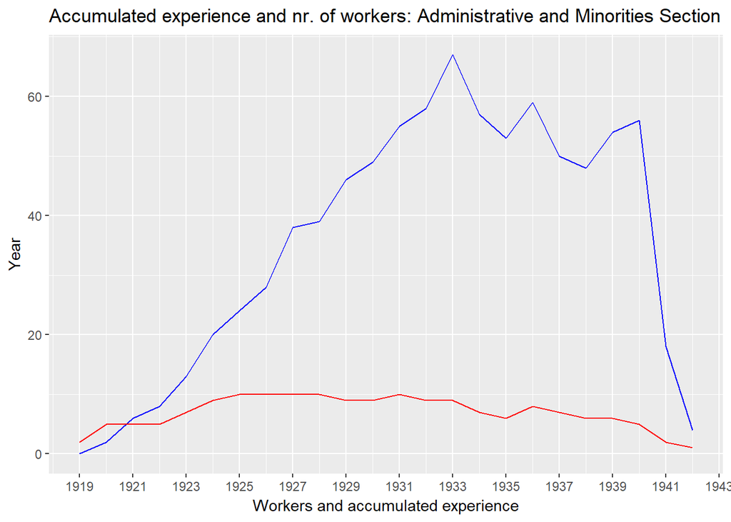

```r
accumulated_experience(filter(large_sections, oname == levels(oname)[1]), group = levels(large_sections$oname)[1])
```

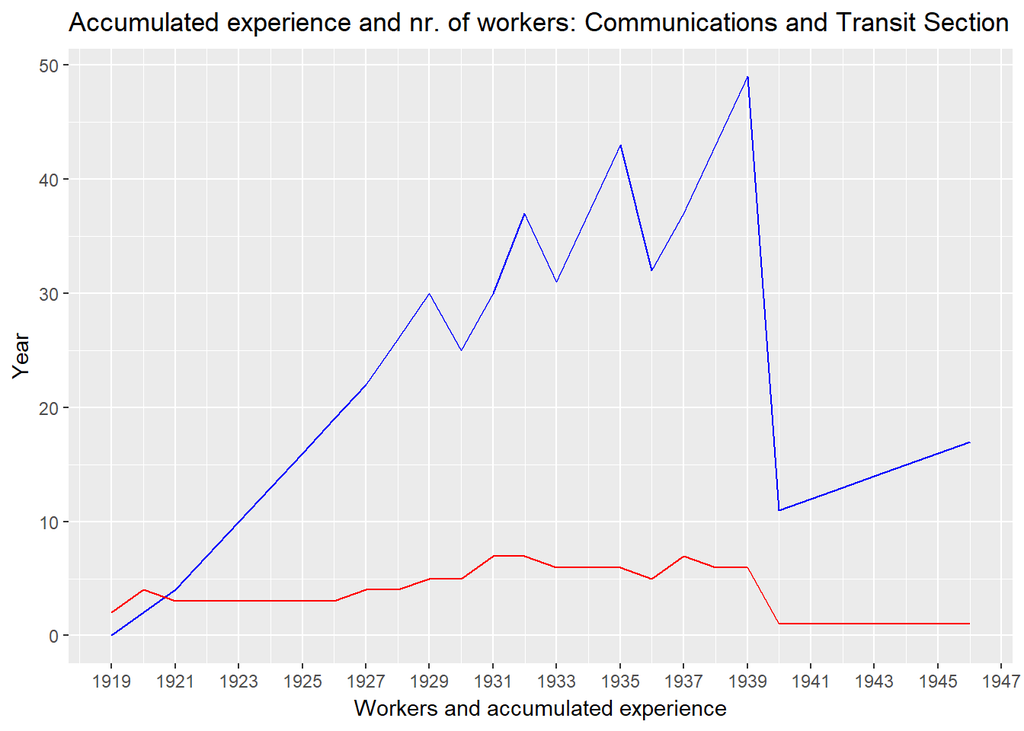

```r
accumulated_experience(filter(large_sections, oname == levels(oname)[2]), group = levels(large_sections$oname)[2])
```

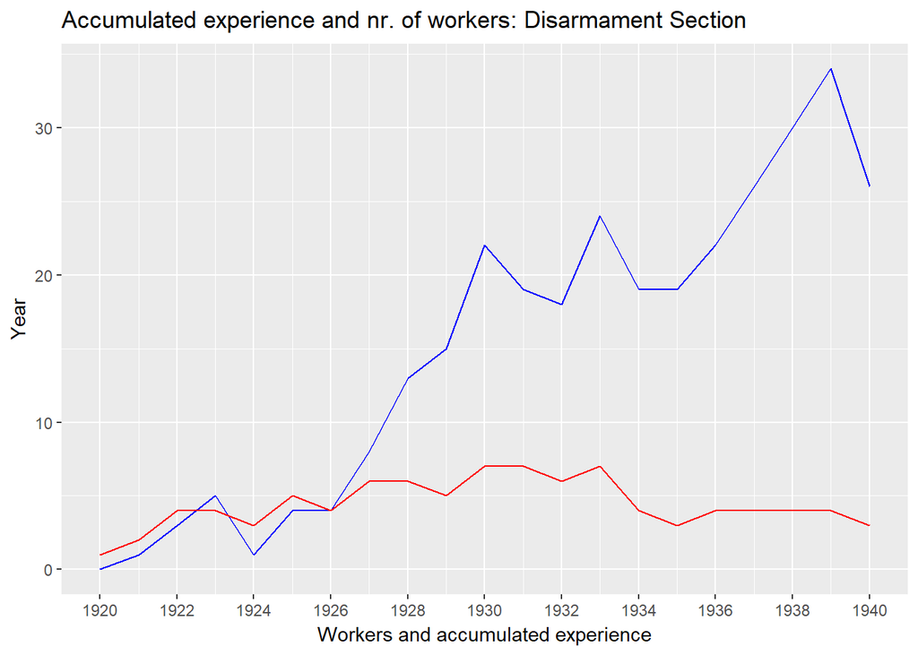

```r
accumulated_experience(filter(large_sections, oname == levels(oname)[3]), group = levels(large_sections$oname)[3])
```

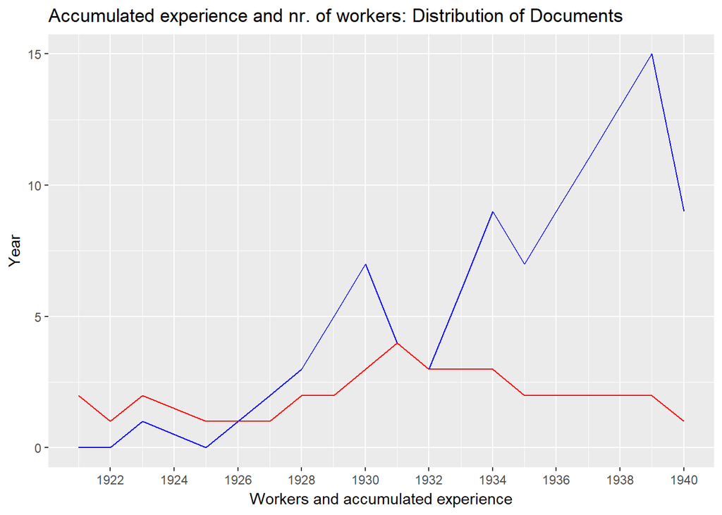

```r
accumulated_experience(filter(large_sections, oname == levels(oname)[4]), group = levels(large_sections$oname)[4])
```

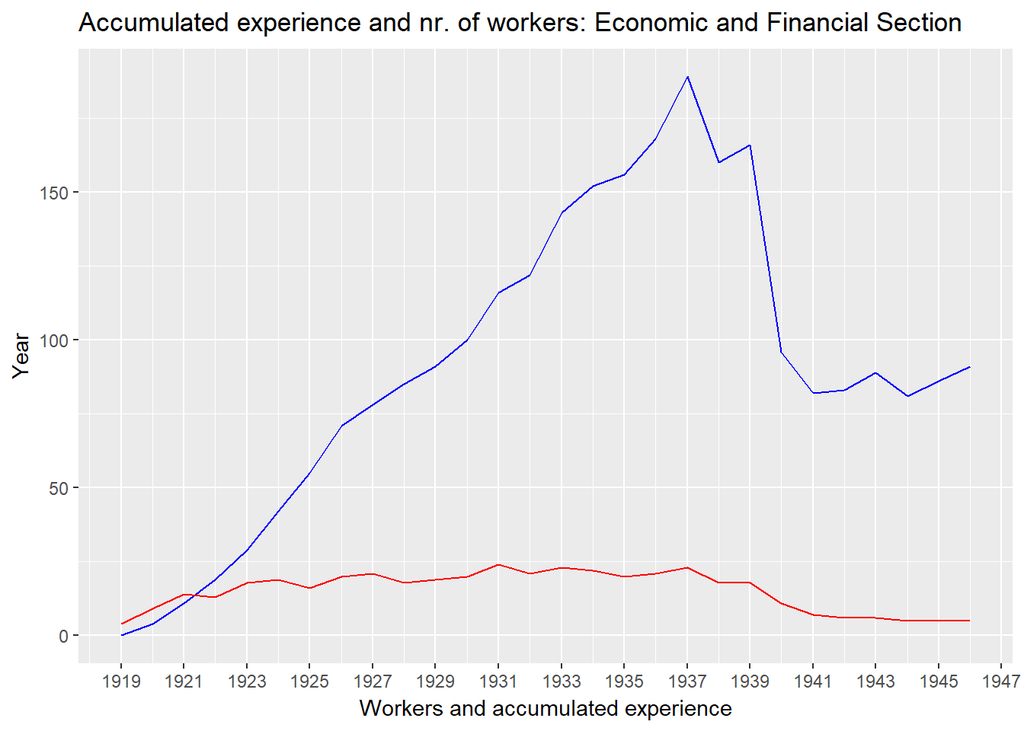

```r
accumulated_experience(filter(large_sections, oname == levels(oname)[5]), group = levels(large_sections$oname)[5])
```

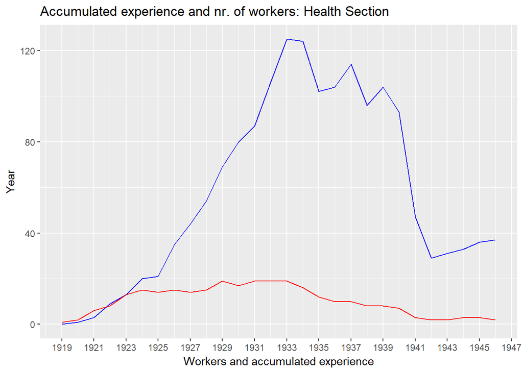

```r
accumulated_experience(filter(large_sections, oname == levels(oname)[6]), group = levels(large_sections$oname)[6])
```

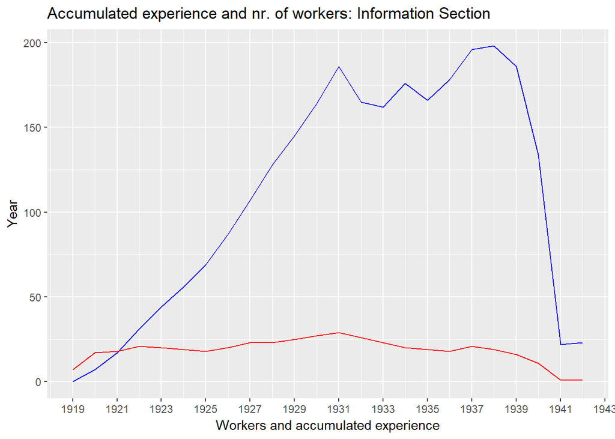

```r
accumulated_experience(filter(large_sections, oname == levels(oname)[7]), group = levels(large_sections$oname)[7])
```

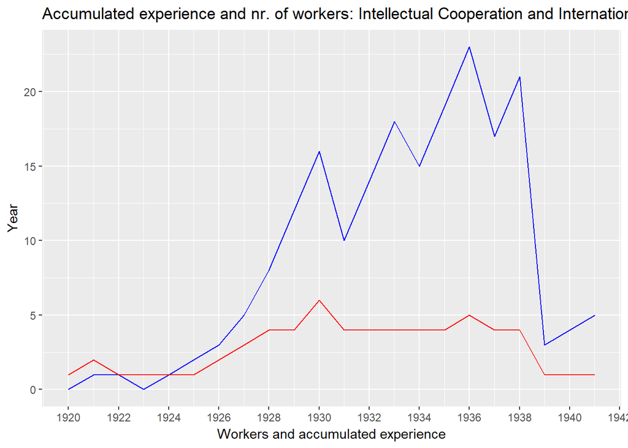

```r
accumulated_experience(filter(large_sections, oname == levels(oname)[8]), group = levels(large_sections$oname)[8])
```

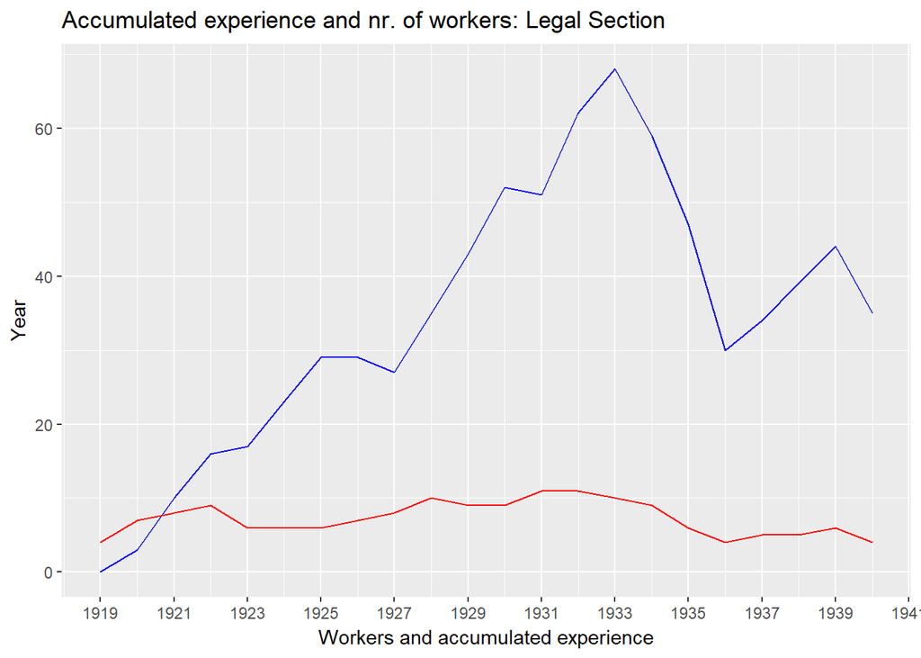

```r
accumulated_experience(filter(large_sections, oname == levels(oname)[9]), group = levels(large_sections$oname)[9])
```

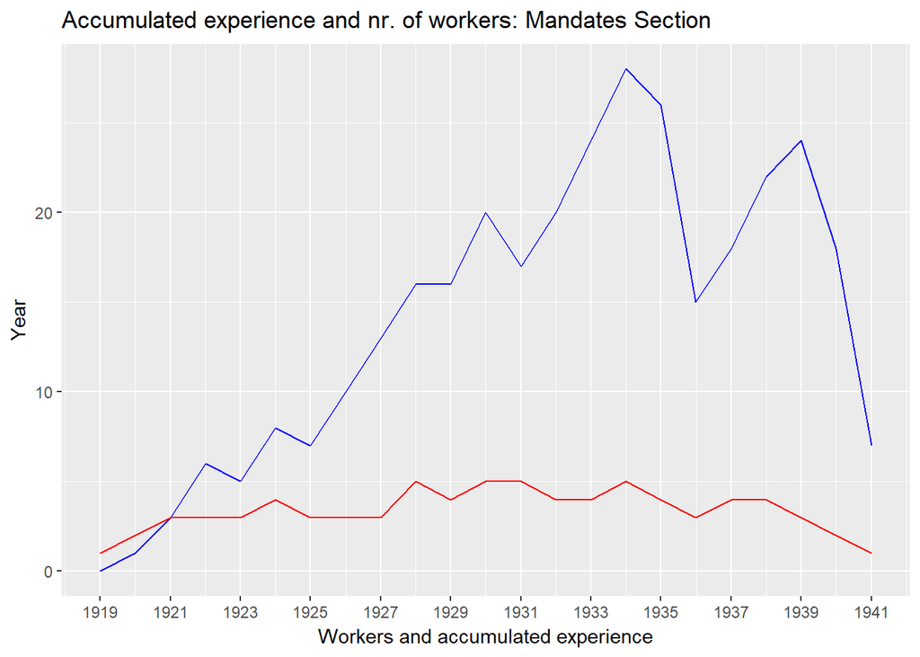

```r
accumulated_experience(filter(large_sections, oname == levels(oname)[10]), group = levels(large_sections$oname)[10])
```

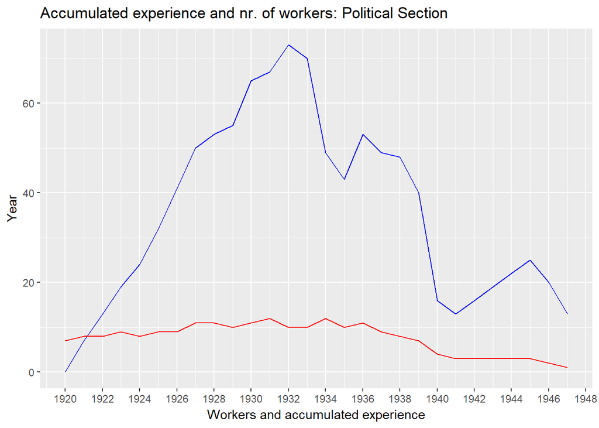

```r
accumulated_experience(filter(large_sections, oname == levels(oname)[11]), group = levels(large_sections$oname)[11])
```

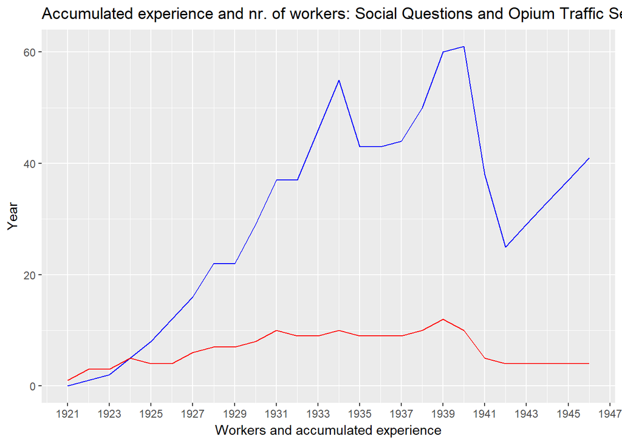

```r
accumulated_experience(filter(large_sections, oname == levels(oname)[12]), group = levels(large_sections$oname)[12])
```

- Number of workers (red) and accumulated experience (blue) per Division.

For first division

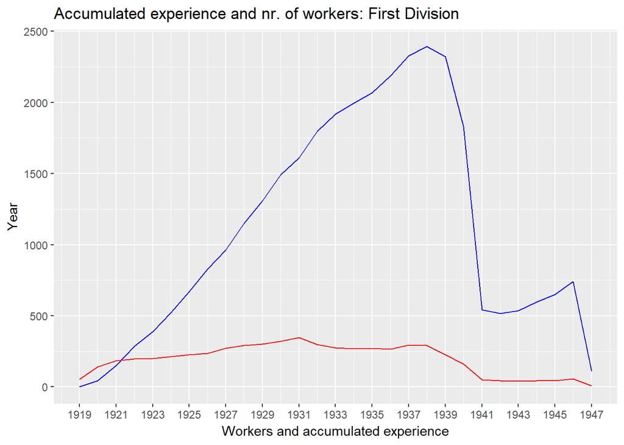

```r
accumulated_experience(filter(da, canonical_fname == "First Division"), group = "First Division")
```

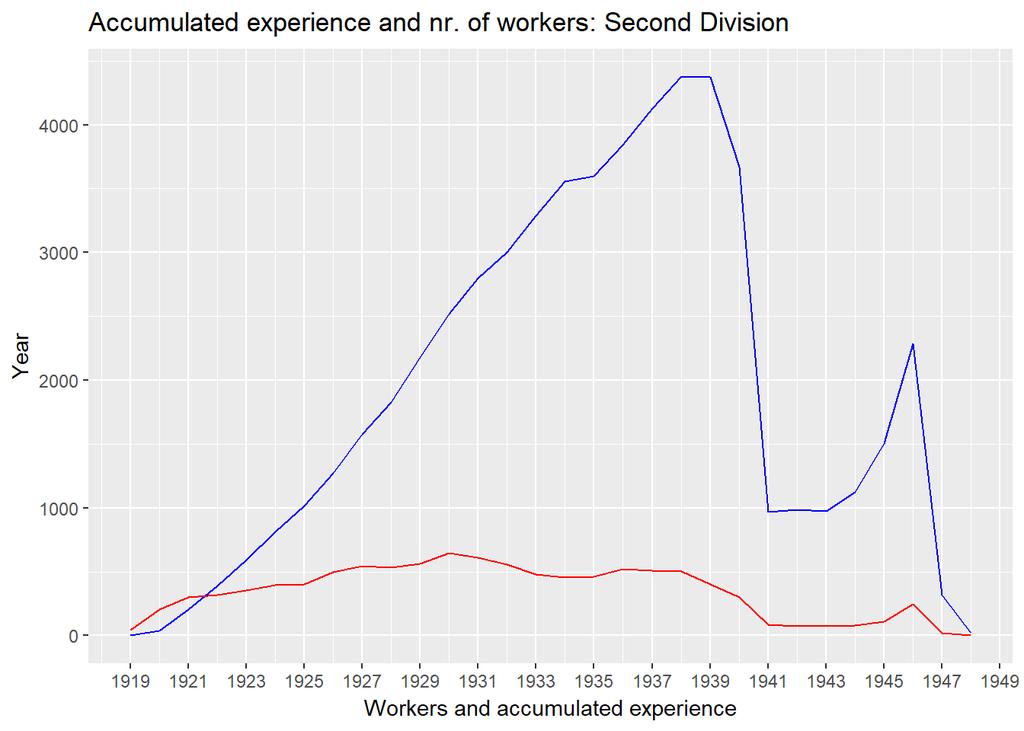

```r
accumulated_experience(filter(da, canonical_fname == "Second Division"), group = "Second Division")
```

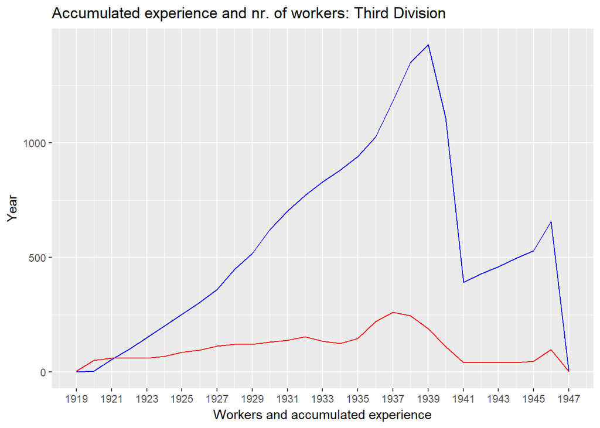

```r
accumulated_experience(filter(da, canonical_fname == "Third Division"), group = "Third Division")
```

- Number of workers (red) and accumulated experience (blue) Groupings of Sections.

Group 1: Social Questions and Opium Traffic Section; Health Section; Communications and Transit Section; Economic and Financial Section; Intellectual Cooperation and International Bureaux Section.

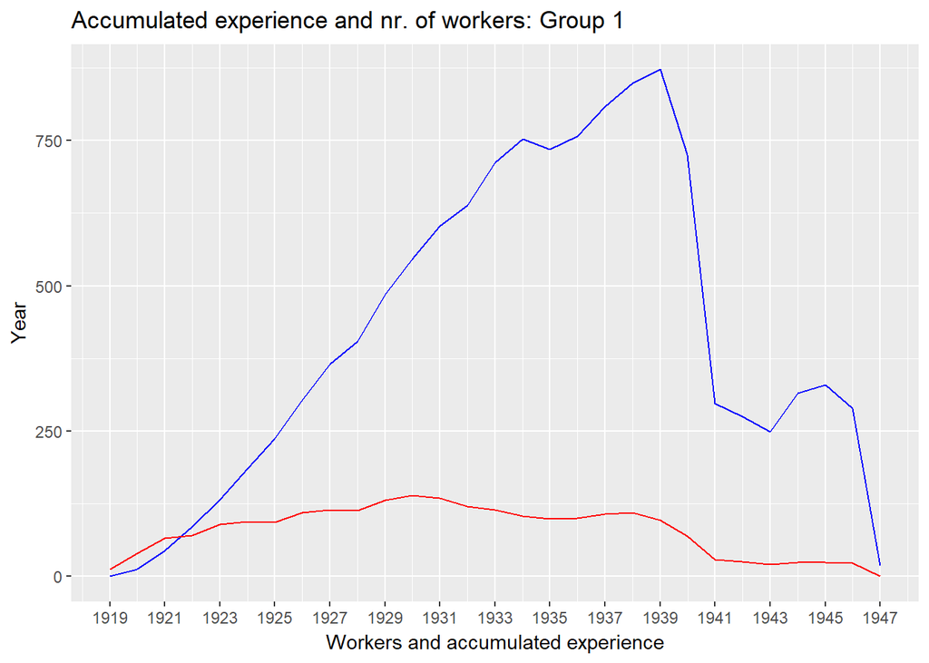

```r
filter(da, oname %in% c("Social Questions and Opium Traffic Section", "Health Section", "Communications and Transit Section", "Economic and Financial Section", "Intellectual Cooperation and International Bureaux Section")) %>%
  accumulated_experience(group = "Group 1")
```

Group 2: Internal Administration

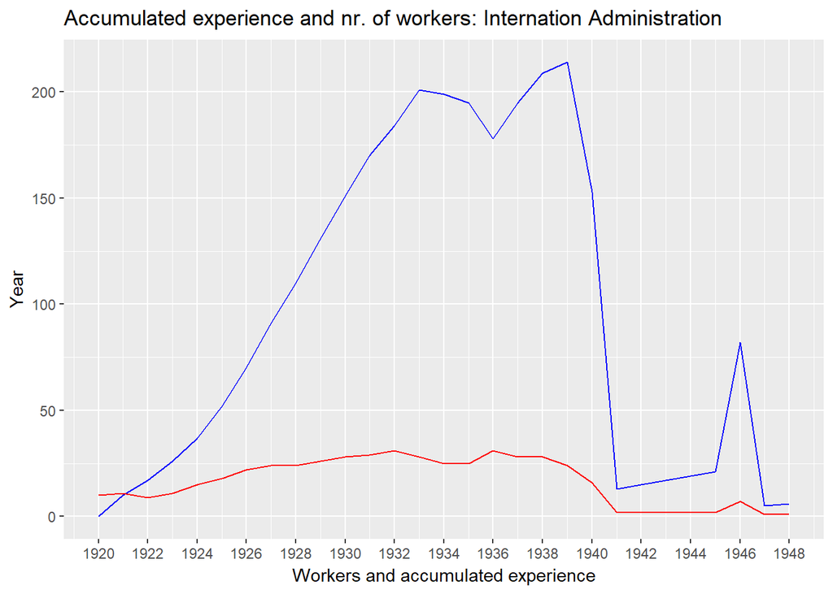

```r
filter(da, oname == "Internal Administration") %>%
  accumulated_experience(group = "Internation Administration")
```

Group 3: Political Section; Information Section; Legal Section; Disarmament Section.

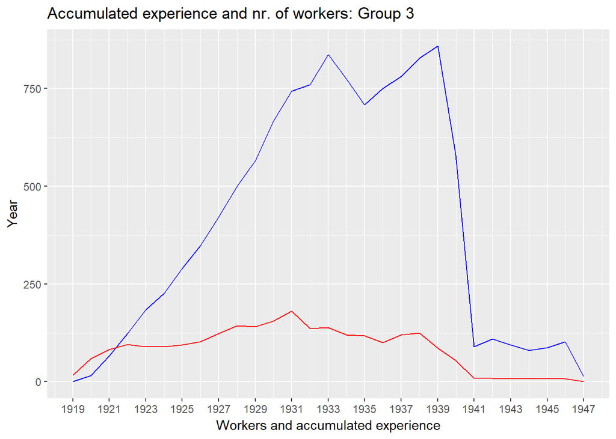

```r
filter(da, oname %in% c("Political Section", "Information Section", "Legal Section", "Disarmament Section" )) %>%
accumulated_experience(group = "Group 3")
```

Group 4: Mandates Section; Administrative Comm. and Minorities Question Section. The last section “Administrative Comm. and Minorities Question Section” has been interpreted as “Administrative and Minorities Section”.

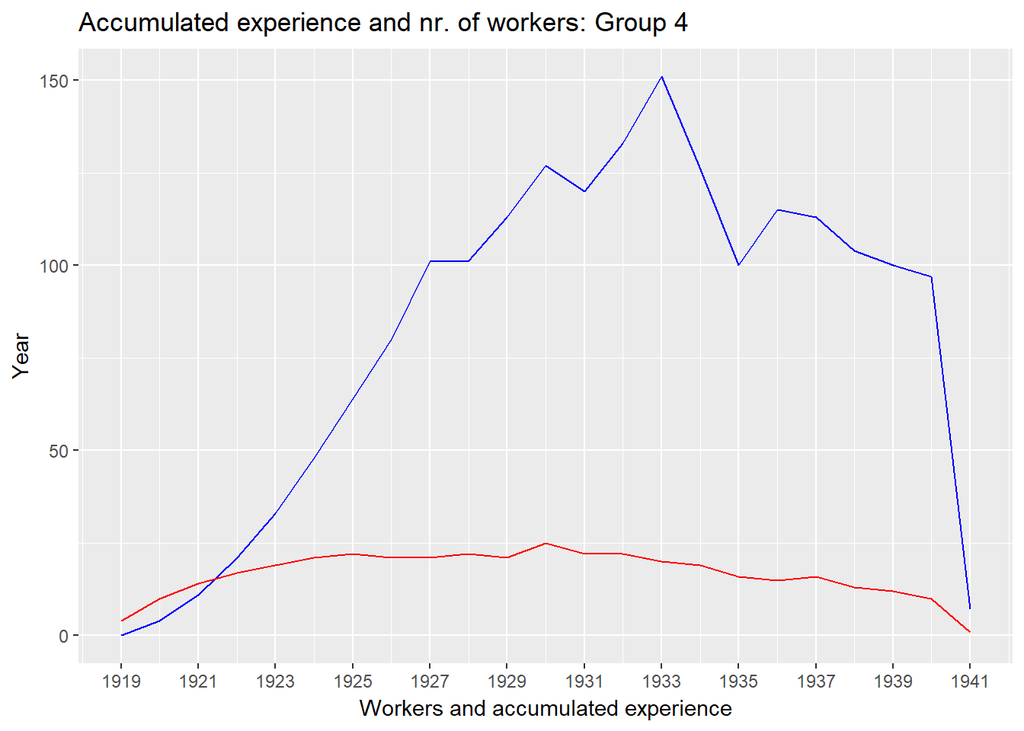

```r
filter(da, oname %in% c("Mandates Section", "Administrative and Minorities Section")) %>%
accumulated_experience(group = "Group 4")
```